# Survival analysis

## Survival analysis

Variable: \(\quad\) time to an event (T), e.g., death, disease progresion, etc.

Problem: \(\quad\) *censored* observations (right-censoring)

- loss to follow-up
- no event by end of fixed study period

Goals:

- describe survival as a function of time: \(\quad\) *Kaplan-Meier* method
- compare survival in different sets of patients: \(\quad\) *log-rank* test
- model survival as a function of covariates (age, sex, treatment, etc.):  
  \(\quad\) *Cox proportional hazards* model

## Right censoring

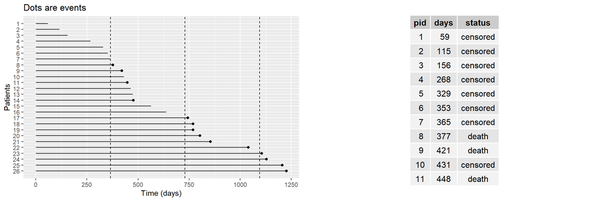

How to represent censoring in a single variable?

How to estimate survival at different times in the presence of censoring?

## Survival and hazard functions

**survival function**: probability of surviving *at least* until time \(t\) \(\qquad \small{S(t) = \text{Prob}(T > t) = 1- F(t)}\)

**hazard function**: instantaneous death / event *rate* at time \(t\) \(\qquad h(t) = \frac{f(t)}{S(t)} = - \frac{d \log S(t)}{d t}\)

**cumulative hazard function**: accumulated risk until time \(t\) \(\quad \quad \quad \small{H(t) = - \log S(t)}\)

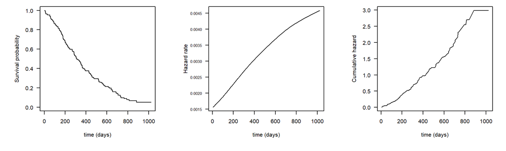

\(h(t)\) is conditional on not having experienced the event before t. It’s *not* a probability.  
\(H(t)\) does not have an easy interpretation.

## Advanced lung cancer

Survival in 228 patients with advanced lung cancer from the North Central Cancer Treatment Group (Journal of Clinical Oncology. 12(3):601-7, 1994).  
See `?lung` for more details.

```r
library(survival)
head(lung, 4)
```

```
  inst time status age sex ph.ecog ph.karno pat.karno meal.cal wt.loss
1    3  306      2  74   1       1       90       100     1175      NA
2    3  455      2  68   1       0       90        90     1225      15
3    3 1010      1  56   1       0       90        90       NA      15
4    5  210      2  57   1       1       90        60     1150      11
```

- time: survival time in days  
- status: censoring status 1=censored, 2=dead  
- sex: Male=1 Female=2

## Survival objects

The `Surv()` function creates suvival objects combining time and censoring/event information. You need to specify:

- `time` (the follow-up time)
- `event` (see `?Surv` for allowed event codings)

The result is a value for each subject: the time followed by + if censored

```r
surv_obj <- Surv(time = lung$time, event = lung$status)        # creates a survival object

head(surv_obj, 20)                                             # prints first 20 values
```

```
 [1]  306   455  1010+  210   883  1022+  310   361   218   166   170   654
[13]  728    71   567   144   613   707    61    88
```

## Kaplan-Meier (KM) curve

The `Survfit` function estimates survival using KM method. You need to specify a *formula* with a survival object (before the tilde), and either 1 (for a single curve) or a factor (for a curve for each level).

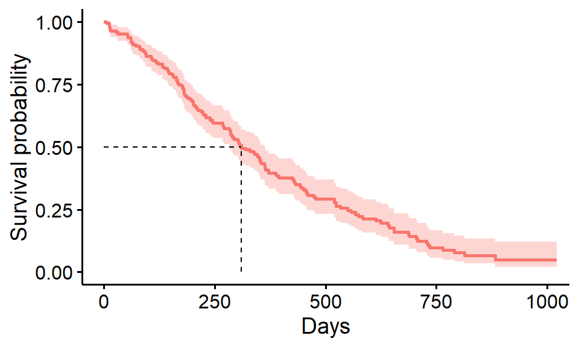

```r
km <- survfit(Surv(time = time, event = status) ~ 1, data = lung)           # KM estimation
library(survminer)
ggsurvplot(km, xlab = "Days", legend = "none",                              # plots  survfit objects
           censor=FALSE, surv.median.line = "hv")
```

See `?ggsurvplot` for more customization options

## KM estimates

- Get KM survival estimates at specific times using function `summary()` on a `survfit` object.
- Get median survival time by printing the `survfit` object

```r
summary(km, time = c(365, 730))     # survival estimates at specified times
```

```
Call: survfit(formula = Surv(time = time, event = status) ~ 1, data = lung)

 time n.risk n.event survival std.err lower 95% CI upper 95% CI
  365     65     121    0.409  0.0358       0.3447        0.486
  730     13      38    0.116  0.0283       0.0716        0.187
```

```r
km                                  # median survival time
```

```
Call: survfit(formula = Surv(time = time, event = status) ~ 1, data = lung)

       n events median 0.95LCL 0.95UCL
[1,] 228    165    310     285     363
```

## KM estimates

- Get other quantiles using the `quantile()` function on the `survfit` object

```r
quantile(km)
```

```
$quantile
 25  50  75
170 310 550

$lower
 25  50  75
145 285 460

$upper
 25  50  75
197 363 654
```

## Log-rank test

To compare survival curves with this test, use function `survdiff()` on a formula, with the factor defining groups after the tilde.

```r
lung <- lung %>% mutate(sex = factor(sex, levels=1:2, labels = c("male", "female")))
survdiff(Surv(time, status) ~ sex, data = lung)      # note formula
```

```
Call:
survdiff(formula = Surv(time, status) ~ sex, data = lung)

             N Observed Expected (O-E)^2/E (O-E)^2/V
sex=male   138      112     91.6      4.55      10.3
sex=female  90       53     73.4      5.68      10.3

 Chisq= 10.3  on 1 degrees of freedom, p= 0.001
```

This test can be used if:

- Groups are independent (different subjects)
- With similar, non-informative censoring pattern, and
- Proportional hazards \(\implies\) curves do not cross

## Survival curves with log-rank test

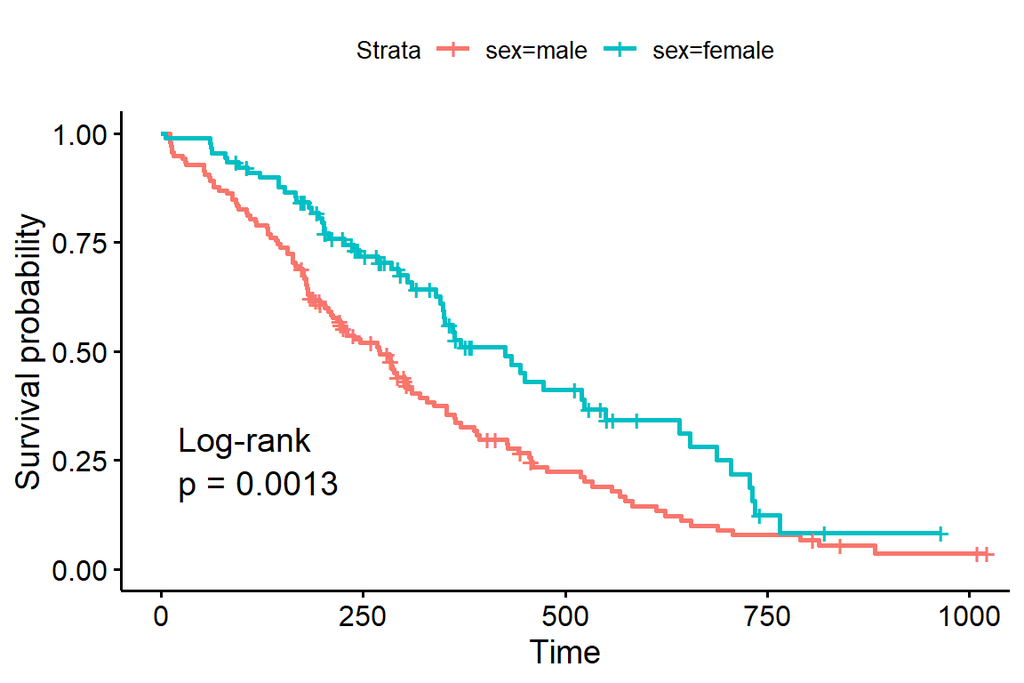

```r
ggsurvplot(survfit(Surv(time, status) ~ sex, data = lung),
           pval = TRUE,                                     # plots the p-value
           pval.method = TRUE)                              # plots the method (test)
```

## Exercise

Using the `ovarian` dataset in package `survival` (see `?ovarian`):

1. Define factors for `rx (1="A", 2="B")`, `resid.ds (1="no", 2="yes")` and `ecog.ps (1="good", 2="bad")`, and factor to dichotomize age, with labels “old” (if age >=50), or “young” (otherwise).
2. Create a survival object from `futime` and `fustat`, and print it.
3. Use this object to fit a KM curve for each treatment group, and plot them using option `risk.table = TRUE` in the `ggsurvplot()` function call.
4. What is the median survival time for each treatment?
5. What are the survival estimates at 1 and 2 years?
6. Compare the two curves with a log-rank test.
7. Examine the predictive value of the residual disease by plotting a survival curve for each residual disease group, showing the result of the log-rank test.